# UFO_R_Markdown

Carlos

2022-09-06

The first step when running a code in R is to install the necessary packages. In this case we will be using the tidyverse package. To install the latest version of this package we run the chunk below:

```r
install.packages("tidyverse",repos = "http://cran.us.r-project.org")
```

We then load the tidyverse package

```r
library("tidyverse")
```

## Data Import

```r
observations_per_country <-read.csv("https://raw.githubusercontent.com/Carly1269/PortfolioProjects/main/UFO_Sightings_Project/UFO_Sightings_SQL_Export/Observations_Per_Country.csv", header=TRUE, stringsAsFactors=FALSE)

observations_per_hour_of_the_day <-read.csv("https://raw.githubusercontent.com/Carly1269/PortfolioProjects/main/UFO_Sightings_Project/UFO_Sightings_SQL_Export/Observations_Per_Hour_of_the_Day.csv", header=TRUE, stringsAsFactors=FALSE)

observations_per_state <-read.csv("https://raw.githubusercontent.com/Carly1269/PortfolioProjects/main/UFO_Sightings_Project/UFO_Sightings_SQL_Export/Observations_Per_State.csv", header=TRUE, stringsAsFactors=FALSE)

observations_per_year <-read.csv("https://raw.githubusercontent.com/Carly1269/PortfolioProjects/main/UFO_Sightings_Project/UFO_Sightings_SQL_Export/Observations_Per_Year.csv", header=TRUE, stringsAsFactors=FALSE)
```

We then print the data to check on the data types

```r
print(observations_per_country)
```

```
##   county_sighting_count country_clean
## 1                 70927            us
## 2                  5969           N/A
## 3                  3436            ca
```

```r
print(observations_per_hour_of_the_day)
```

```
##    hour_observed number_of_observations
## 1             21                  11445
## 2             22                  10837
## 3             20                   8617
## 4             23                   7953
## 5             19                   6147
## 6              0                   4108
## 7             18                   4002
## 8              1                   3210
## 9             17                   2592
## 10             2                   2357
## 11             3                   2004
## 12            16                   1620
## 13             5                   1591
## 14             4                   1529
## 15            15                   1433
## 16            12                   1368
## 17            14                   1322
## 18            13                   1303
## 19             6                   1224
## 20            10                   1166
## 21            11                   1144
## 22             9                    958
## 23             7                    905
## 24             8                    803
## 25            NA                    694
```

```r
print(observations_per_state)
```

```
##    sate_sighting_count stateid
## 1                 9655      ca
## 2                 4266      wa
## 3                 4200      fl
## 4                 3677      tx
## 5                 3219      ny
## 6                 2689      az
## 7                 2645      il
## 8                 2582      pa
## 9                 2424      oh
## 10                2071      mi
## 11                1868      nc
## 12                1845      or
## 13                1584      on
## 14                1576      mo
```

[output cut: 54 more lines]

```r
print(observations_per_year)
```

```
##    year_observed number_of_observations
## 1           2012                   7308
## 2           2013                   6992
## 3           2011                   5077
## 4           2008                   4777
## 5           2009                   4508
## 6           2010                   4258
## 7           2007                   4243
## 8           2004                   4220
## 9           2005                   4039
## 10          2003                   3935
## 11          2006                   3682
## 12          2002                   3211
## 13          2001                   3109
## 14          1999                   2788
```

[output cut: 74 more lines]

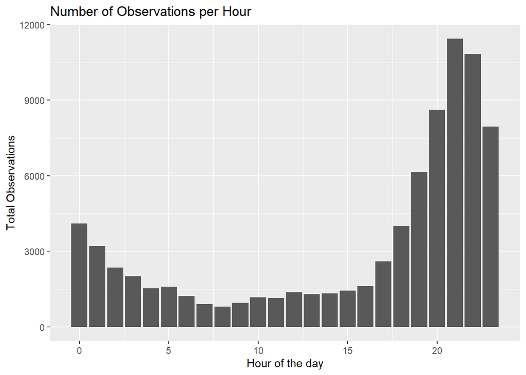

```r
ggplot(data =observations_per_hour_of_the_day, mapping = aes(x=hour_observed, y=number_of_observations))+ geom_bar(stat = "identity")+labs(title = "Number of Observations per Hour",x="Hour of the day",y="Total Observations")
```

As we can see most observations happen during the night time.

We will then graph the data of the total number of observations per state:

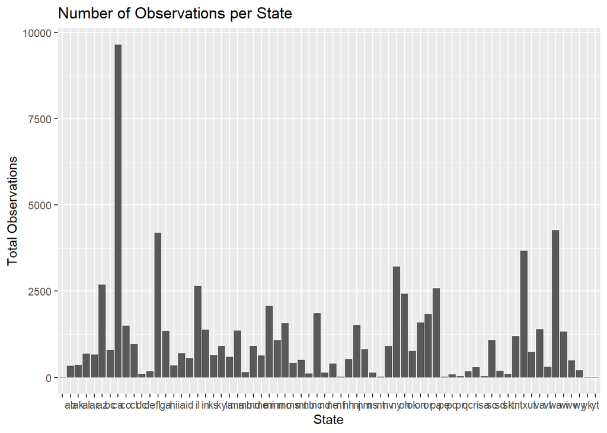

```r
ggplot(data =observations_per_state, mapping = aes(x=stateid, y=sate_sighting_count))+ geom_bar(stat = "identity")+labs(title = "Number of Observations per State",x="State",y="Total Observations")
```

We can see that the data varies a lot. To visualize it better we will order the states from the most number of observations to the least. We will also tilt the state ids for better visualization

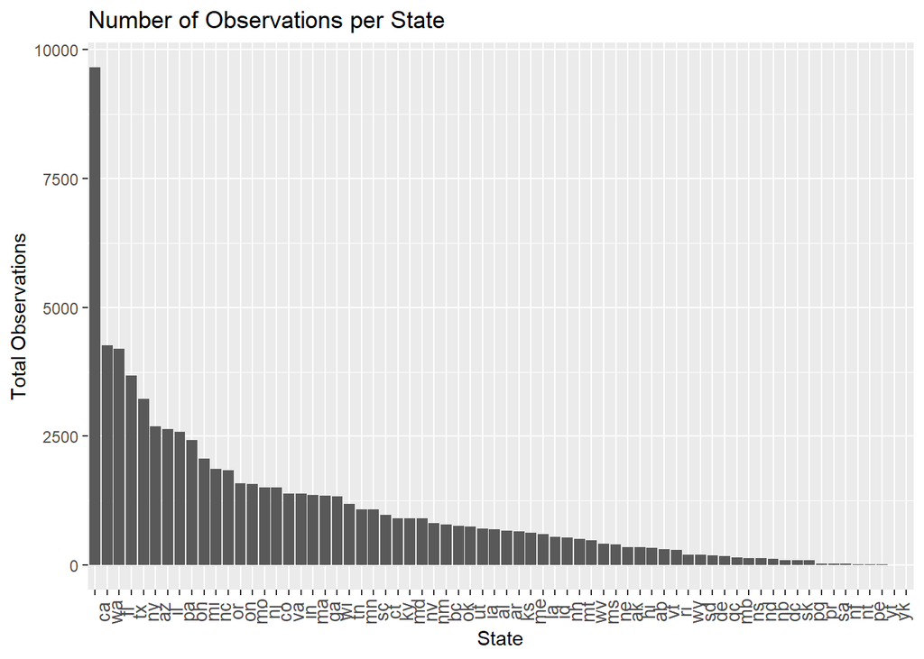

```r
ggplot(data =observations_per_state, mapping = aes(x=reorder(stateid,-sate_sighting_count), y=sate_sighting_count))+ geom_bar(stat = "identity")+theme(axis.text.x = element_text(size = 10, angle = 90))+labs(title = "Number of Observations per State",x="State",y="Total Observations")
```

We can see that the state of California has the most number of observations. Followed by the state of Washington

We will then graph the total number of observations per year

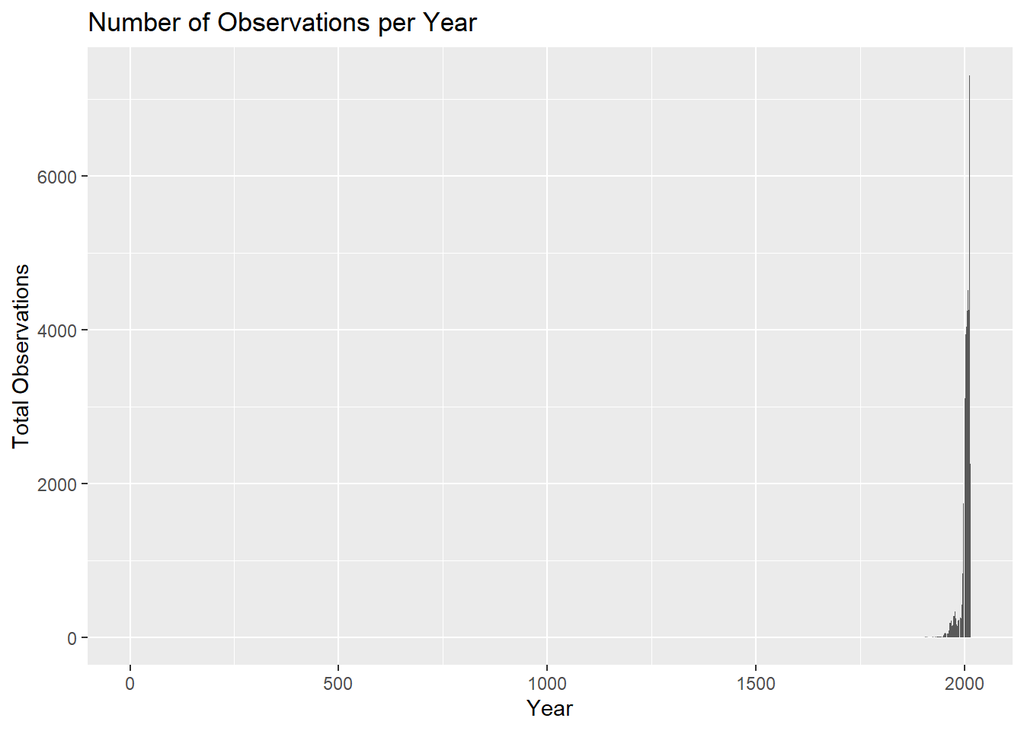

```r
ggplot(data =observations_per_year, mapping = aes(x=year_observed, y=number_of_observations))+ geom_bar(stat = "identity")+labs(title = "Number of Observations per Year",x="Year",y="Total Observations")
```

The graph is really hard to visualize since we have observations from thousands of years in the past. We will zoom into our graph to better see our data

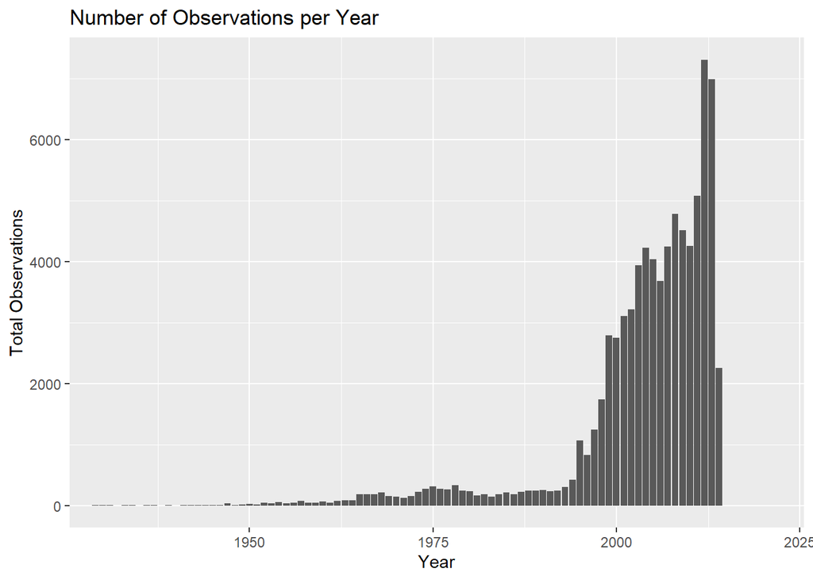

```r
ggplot(data =observations_per_year, mapping = aes(x=year_observed, y=number_of_observations))+ geom_bar(stat = "identity")+coord_cartesian(xlim = c(1930,2021))+labs(title = "Number of Observations per Year",x="Year",y="Total Observations")
```